# Spatio-temporal modelling

```r
# rm(list=ls())

library(inlabru)
init.tutorial()
library(rgdal)
library(ggmap) # for fancy plotting
library(INLA)
library(RColorBrewer)
```

Make a shortcut to a nicer colour scale:

```r
colsc <- function(...) {
  scale_fill_gradientn(colours = rev(RColorBrewer::brewer.pal(11,"RdYlBu")),
                       limits = range(..., na.rm=TRUE))
}
```

Read in the data

```r
load("Nigeria/terror_data.RData")
terror.data<-data[data$country=='NGA',]
```

look at it

```r
head(terror.data)
```

```
##     nkill latitude longitude iyear       alt      distb        pop
## 20      1 5.116561  7.367093  2010 -1.025901 -0.1898097  0.5460390
## 126     0 4.723092  6.778945  2010 -1.077529 -0.6233167 -0.3231028
## 127     0 4.723092  6.778945  2010 -1.077529 -0.6233167 -0.3231028
## 128     0 4.723092  6.778945  2010 -1.077529 -0.6233167 -0.3231028
## 573     7 9.066667  7.483333  2010  1.586220  3.2766813 -0.2741496
## 574     4 9.066667  7.483333  2010  1.586220  3.2766813 -0.2741496
##             tt     ethrq        lum        pol country        slo
## 20  -0.5063343 0.6935829  0.5975054 -0.9556017     NGA  0.4296647
## 126 -0.1242832 0.8180201 -0.8130734 -0.9556017     NGA -3.1303970
## 127 -0.1242832 0.8180201 -0.8130734 -0.9556017     NGA -3.1303970
## 128 -0.1242832 0.8180201 -0.8130734 -0.9556017     NGA -3.1303970
## 573 -0.4554338 0.7926396  0.7582696 -0.9556017     NGA -3.1302539
## 574 -0.4554338 0.7926396  0.7582696 -0.9556017     NGA -3.1302539
##       x.coord   y.coord    z.coord
## 20  0.9877932 0.1277151 0.08918219
## 126 0.9896370 0.1176382 0.08234018
## 127 0.9896370 0.1176382 0.08234018
## 128 0.9896370 0.1176382 0.08234018
## 573 0.9790949 0.1286105 0.15758359
## 574 0.9790949 0.1286105 0.15758359
```

```r
class(terror.data)
```

```
## [1] "data.frame"
```

```r
studyarea<-studyarea[studyarea$sov_a3=='NGA',]
data<-data[data$country=='NGA',]
bdry <- inla.sp2segment(studyarea)
bdry$loc <- inla.mesh.map(bdry$loc)
```

this is quite a rough mesh; used here to avoid long running times during the practical

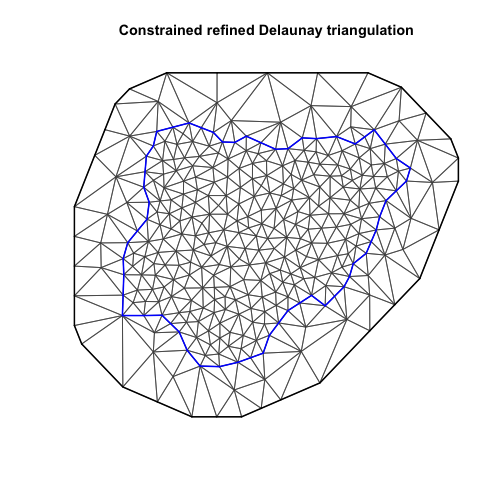

```r
mesh3<-inla.mesh.2d(boundary=bdry, max.edge=c(80,6000)/180,cutoff=80/180,
                    crs=CRS(proj4string(studyarea))) #nv=330
plot(mesh3)
```

```r
terror.data <- terror.data[terror.data$iyear>=2010 & terror.data$iyear<=2015,]
round.to <- function(x, b) {round(x/b)*b}
terror.data$originalnkill<-round.to(terror.data$nkill, 1)#some observations have non-integer values
terror.data$originallethal<-ifelse(terror.data$originalnkill==0,0,1)
resp.bern<- terror.data$originallethal
```

The data are stored as a `data.frame` and the columns holding the coorinates are called `longitude` and `latitude`. Using this information we can convert the data into a `SpatialPointsDataFrame` object

```r
coordinates(terror.data) = c("longitude","latitude")
```

The object `terror.data` now is in the proper format:

```r
class(terror.data)
```

```
## [1] "SpatialPointsDataFrame"
## attr(,"package")
## [1] "sp"
```

and the coordinates of each point are equivalent to the previous `Lat` and `Long`:

```r
head(terror.data)
```

```
##              coordinates nkill iyear       alt      distb        pop
## 20  (7.367093, 5.116561)     1  2010 -1.025901 -0.1898097  0.5460390
## 126 (6.778945, 4.723092)     0  2010 -1.077529 -0.6233167 -0.3231028
## 127 (6.778945, 4.723092)     0  2010 -1.077529 -0.6233167 -0.3231028
## 128 (6.778945, 4.723092)     0  2010 -1.077529 -0.6233167 -0.3231028
## 573 (7.483333, 9.066667)     7  2010  1.586220  3.2766813 -0.2741496
## 574 (7.483333, 9.066667)     4  2010  1.586220  3.2766813 -0.2741496
##             tt     ethrq        lum        pol country        slo
## 20  -0.5063343 0.6935829  0.5975054 -0.9556017     NGA  0.4296647
## 126 -0.1242832 0.8180201 -0.8130734 -0.9556017     NGA -3.1303970
## 127 -0.1242832 0.8180201 -0.8130734 -0.9556017     NGA -3.1303970
## 128 -0.1242832 0.8180201 -0.8130734 -0.9556017     NGA -3.1303970
## 573 -0.4554338 0.7926396  0.7582696 -0.9556017     NGA -3.1302539
## 574 -0.4554338 0.7926396  0.7582696 -0.9556017     NGA -3.1302539
##       x.coord   y.coord    z.coord originalnkill originallethal
## 20  0.9877932 0.1277151 0.08918219             1              1
## 126 0.9896370 0.1176382 0.08234018             0              0
## 127 0.9896370 0.1176382 0.08234018             0              0
## 128 0.9896370 0.1176382 0.08234018             0              0
## 573 0.9790949 0.1286105 0.15758359             7              1
## 574 0.9790949 0.1286105 0.15758359             4              1
```

Moreover, the names of the coordinates are still available using

```r
coordnames(terror.data)
```

```
## [1] "longitude" "latitude"
```

There is one more thing to take care of. So far we have only told the object which columns to take the coordinates from. However, it is still unaware of how to interpret these coordinates since it does not know which coordinate reference system was used when the data were stored:

```r
proj4string(terror.data)
```

```
## [1] NA
```

The data are stored as coordinates in longitude and latitude so the corresponding proj4string is `+proj=longlat`

```r
proj4string(terror.data) = "+proj=longlat"
```

Finally, we make the mesh live in the same CRS:

```r
mesh3$crs <- inla.CRS("+proj=longlat")
```

Plot the sampling locations and the mesh

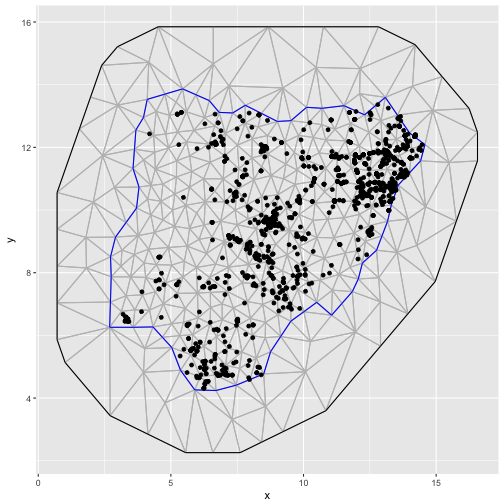

```r
ggplot() + gg(mesh3) + gg(terror.data)
```

… on a map:

[figure not shown]

```r
gmap(terror.data) + gg(mesh3) + gg(terror.data)
```

We will now set up a spatio-temporal model. In order to do so, we must define a temporal index (must be an integer, starting at 1) and the number of discrete time points we want to model (the first line is currently needed because of a bug; in the future it will either be unnecessary or replaced by something else):

```r
terror.data$Year <- terror.data$iyear - min(terror.data$iyear) + 1
Year <- terror.data$Year
nyear <- length(unique(terror.data$Year))
```

The spatio-temporal model is set up as follows. The `alpha=1.5` parameter specifies an exponential covariance model.

```r
cmp.terror = originallethal ~ Intercept+ myspde(map = coordinates,
                                    group = Year,
                                    ngroup = nyear,
                                    model = inla.spde2.pcmatern(mesh3, alpha=1.5,
                                                                prior.range=c(0.1,0.01),
                                                                prior.sigma=c(1,0.01)),
                                    mesh = mesh3,
                                    control.group=list(model="ar1"))
```

Using this model we run a Binomial regression with `bru`

```r
bru.terror = bru(cmp.terror,
            family = "binomial",
             data= terror.data)
```

Check the resulting parameter estimates

```r
summary(bru.terror)
```

[output not shown]

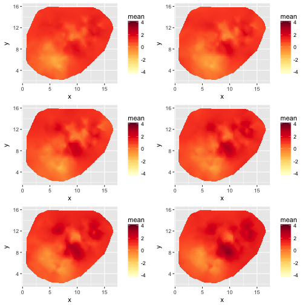

```r
df <- pixels(mesh3)
df1 <- SpatialPixelsDataFrame(df, data.frame(Year=rep(1, nrow(coordinates(df)))),
                              proj4string=CRS(proj4string(mesh3)))
df2 <- SpatialPixelsDataFrame(df, data.frame(Year=rep(2, nrow(coordinates(df)))),
                              proj4string=CRS(proj4string(mesh3)))
df3 <- SpatialPixelsDataFrame(df, data.frame(Year=rep(3, nrow(coordinates(df)))),
                              proj4string=CRS(proj4string(mesh3)))
df4 <- SpatialPixelsDataFrame(df, data.frame(Year=rep(4, nrow(coordinates(df)))),
                              proj4string=CRS(proj4string(mesh3)))
df5 <- SpatialPixelsDataFrame(df, data.frame(Year=rep(5, nrow(coordinates(df)))),
                              proj4string=CRS(proj4string(mesh3)))
df6 <- SpatialPixelsDataFrame(df, data.frame(Year=rep(6, nrow(coordinates(df)))),
                              proj4string=CRS(proj4string(mesh3)))

logint1 = predict(bru.terror, df1, ~ (myspde + Intercept))
logint2 = predict(bru.terror, df2, ~ (myspde + Intercept))
logint3 = predict(bru.terror, df3, ~ (myspde + Intercept))
logint4 = predict(bru.terror, df4, ~ (myspde + Intercept))
logint5 = predict(bru.terror, df5, ~ (myspde + Intercept))
logint6 = predict(bru.terror, df6, ~ (myspde + Intercept))

csc = scale_fill_gradientn(colours = brewer.pal(9,"YlOrRd"), limits=c(-4, 4))

# Note: gg by default picks the first variable in the output, but that's not
#       necessarily the mean; in this case we need to specify it:
multiplot(ggplot() + gg(logint1, mapping = aes_string(fill = "mean")) + csc,
          ggplot() + gg(logint2, mapping = aes_string(fill = "mean")) + csc,
          ggplot() + gg(logint3, mapping = aes_string(fill = "mean")) + csc,
          ggplot() + gg(logint4, mapping = aes_string(fill = "mean")) + csc,
          ggplot() + gg(logint5, mapping = aes_string(fill = "mean")) + csc,
          ggplot() + gg(logint6, mapping = aes_string(fill = "mean")) + csc,
          cols = 3, layout= matrix(c(1,2,3,4,5,6), nrow=3, byrow=TRUE))
```